# Figure 1 Gregor et al

The following is the code to create the figures in the paper “Mammalian gut metabolomes mirror microbiome composition and host phylogeny”

Load packages

```r
library(phyloseq)
library(vegan)
library(ggplot2)
library(dplyr)
library(reshape2)
library(tidyr)
```

Load phyloseq objects and metadata

```r
#metadata
metadata <- read.delim("metadata.txt", header = T, sep = "") ## load metadata file
metadata <-subset(metadata, Type=="Feces")
metadata <- droplevels(metadata)


#16S sequencing results
ps_asv <- readRDS("Phyloseq_files/ps_asv.rds")

#LC-MS/MS metabolomics data (fecal samples, filtered to ~10k fecal peaks)
ps_pol <- readRDS("Phyloseq_files/ps_pol.rds")

#GC-MS metabolomics data (fecal samples)
ps_gcms <- readRDS("Phyloseq_files/ps_gcms.rds")

# PICRUSt data
ps_picrust <- readRDS("Phyloseq_files/ps_picrust.rds")

##Additional files
#LC-MS/MS metabolomics data, all samples and peaks
#ps_polar_all <- readRDS("Phyloseq_files/ps_polar_all.rds")

#GC-MS data, all samples
#ps_gcms_all <- readRDS("Phyloseq_files/ps_gcms_all.rds")
```

##Figure 1A- PCoAs

Create palettes for color (mammalian order) and shape (diet) (colors are from Okabe Ito scale)

```r
colorlist <- c(
  "#0072B2", #Artiodactyla
  "#CC79A7", #Carnivora
  "#009E73", #Perissodactyla
  "#F0E442", #Primates
  "#56B4E9" #Proboscidea
)

shapelist <- c(
  15, #Carnivores
  16,  # Herbivores
  17  #Omnivores
  )
```

PCoA analysis

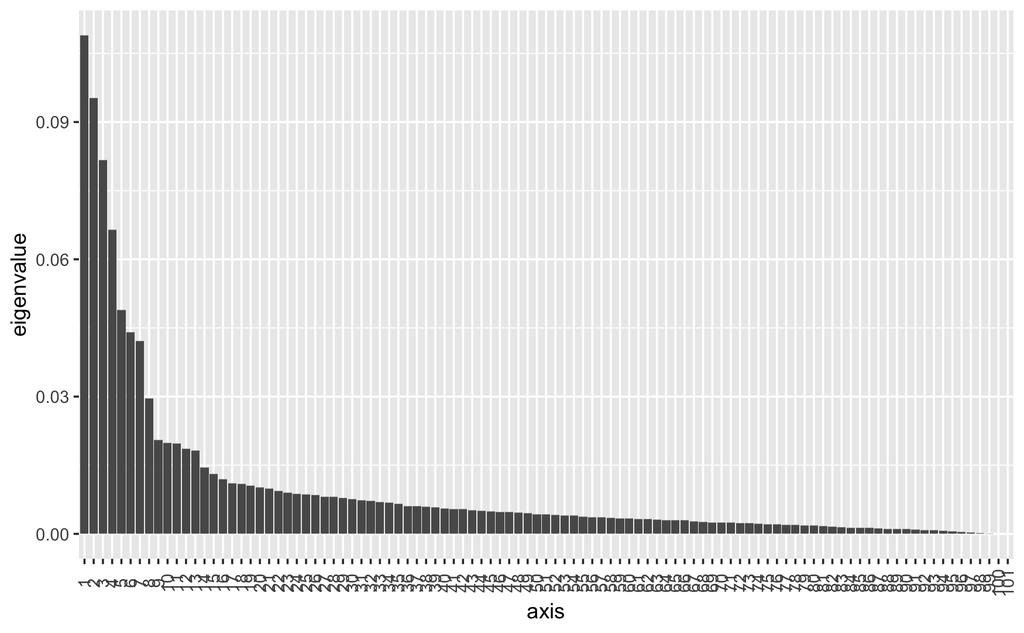

```r
#Choose a phyloseq object to work with: ps_gcms, ps_asv, or ps_pol
ps <- ps_asv

#Apply Bray Curtis ordination

ps.ord <- ordinate(ps, "PCoA", "bray")

#Or, apply alternate ordinations as shown in the SI
#ps.ord <- ordinate(ps, "PCoA", "euclidean")
#ps.ord <- ordinate(ps, "PCoA", "jaccard", binary=TRUE)
#ps.ord <- ordinate(ps, "PCoA", "wunifrac") ##16S only
#ps.ord <- ordinate(ps, "PCoA", "unifrac") ##16S only

##Examine eigenvalues
plot_ordination(ps, ps.ord, type= "scree")
```

```r
##Create list of eigenvalues to normalize the axes
evals <- ps.ord$values[,1]
```

Make the plot object with ggplot2

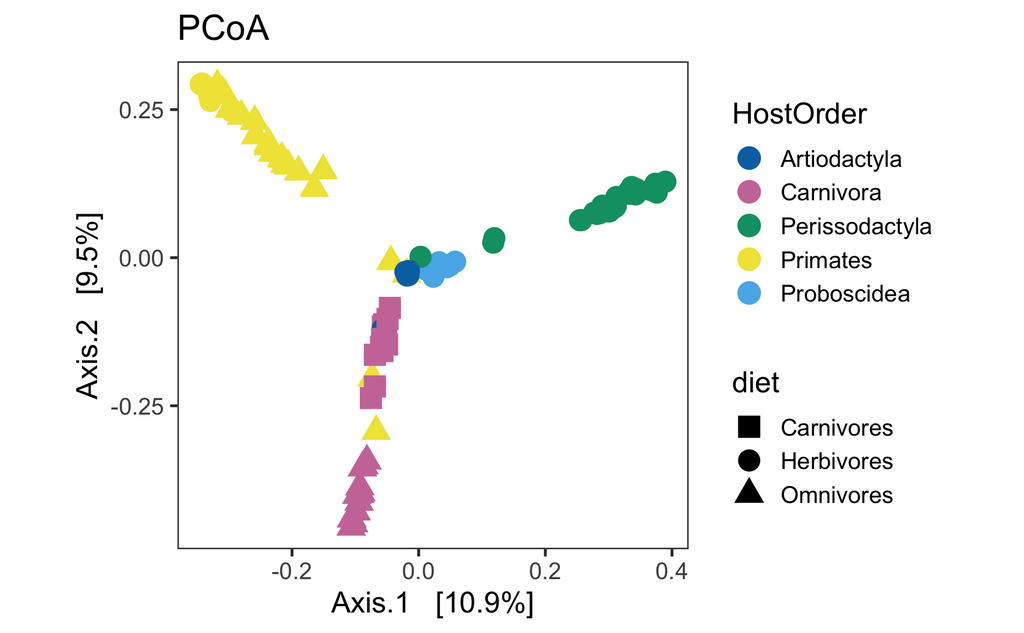

```r
p <- plot_ordination(ps, ps.ord, color = "HostOrder", shape= "diet", title= "PCoA")

p_final <- p +
  coord_fixed(sqrt(evals[2] / evals[1])) +
  theme_bw(base_size=15)+
  theme(panel.grid.major = element_blank(),panel.grid.minor = element_blank())+
  scale_color_manual(values=colorlist) +
  scale_shape_manual(values=shapelist)+
  geom_point(size=5)
p_final
```

##Figure 1B- Trees

Setup. This code closely follows examples laid out in the dendextend vignettes: https://cran.r-project.org/web/packages/dendextend/vignettes/dendextend.html#comparing-two-dendrograms

```r
library(ape)
library(dendextend)
```

For species with multiple individuals, we took the median values using dplyr to create a representative sample for the tree

```r
##Choose which phyloseq object to analyze (ps_gcms, ps_pol, ps_asv)
##eg 16S (ps_asv)
ps <- ps_asv

##The melting step is slow for large files, be patient
ps.m <- psmelt(ps)

ps.m <- ps.m %>% group_by(OTU, HostSpecies_taxonomy) %>% summarise_at(vars(Abundance), median, na.rm=TRUE)

#Reshape from long to wide format (unmelt)
m <- spread(ps.m, key= OTU, value= Abundance)

#give it rownames
m2 <- as.matrix(m[, -1])
rownames(m2) <- m$HostSpecies_taxonomy

##save median values as a new object: gcms_med, pol_med, asv_med
ps_med <- m2
```

Create the trees from the median data.

```r
##Cluster the median data
hclust.ps <- hclust(vegdist(ps_med, method = "bray"), method="ward.D2")

##Import host phylogeny
phylo_hosts <-read.tree(file="species.nwk")

##Convert to dendrograms for dendextend

dend_host <- as.dendrogram(phylo_hosts)
dend_ps <- as.dendrogram(hclust.ps)
```

Make each tanglegram by pairing dend_host with the tree from each dataset. Colored lines highlight subtrees present in both.

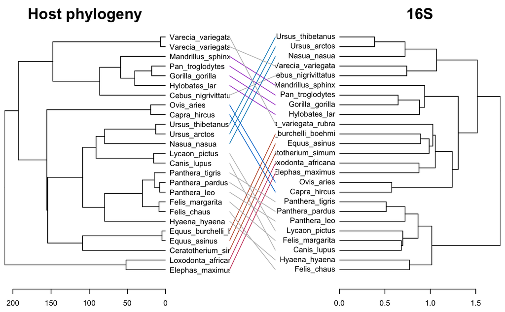

```r
##make a dendlist with the two dendrograms to compare: eg host phylogeny and 16S
dendlist <- dendlist(dend_host, dend_ps)

tanglegram(dendlist, sort=T, main_left = "Host phylogeny", main_right = "16S", common_subtrees_color_branches = FALSE, lwd=1, lab.cex= 1, margin_inner = 7, main="", columns_width= c(5,1,5), highlight_branches_lwd=FALSE, highlight_distinct_edges=FALSE)
```

```r
#How is the entanglement (quality of alignment, lower is better)?
dendlist %>% entanglement
```

```
[1] 0.2289922
```

```r
#Correlation

cor.dendlist(dendlist, method_coef = "pearson")
```

```
         [,1]     [,2]
[1,] 1.000000 0.458519
[2,] 0.458519 1.000000
```

Since the observations creating the Baker’s Gamma Index of such a measure are correlated, we need to perform a permutation test for the calculation of the statistical significance of the index. We will look at the distribution of Baker’s Gamma Index under the null hypothesis (assuming fixed tree topologies). This will be different for different tree structures and sizes. Here are the results when the compared tree is compared to itself after shuffling its own labels (the_cor, correlation of 1), and when comparing tree 1 to the shuffled tree 2 (the_cor2):

```r
set.seed(42)
the_cor <- cor_bakers_gamma(dend_ps, dend_ps)
the_cor2 <- cor_bakers_gamma(dend_ps, dend_host)
the_cor
```

```
[1] 1
```

```r
the_cor2
```

```
[1] 0.2038067
```

Create the null model.

```r
dend_mixed <- dend_ps

R <- 1000
cor_bakers_gamma_results <- numeric(R)


for(i in 1:R) {
   dend_mixed <- sample.dendrogram(dend_mixed, replace = FALSE)
   cor_bakers_gamma_results[i] <- cor_bakers_gamma(dend_host, dend_mixed)
}

##Create plot to show results
plot(density(cor_bakers_gamma_results),
     main = "16S to host phylogeny, Baker's gamma distribution under H0",
     xlim = c(-1,1))
abline(v = 0, lty = 2)
```

```r
abline(v = the_cor, lty = 2, col = 2)
abline(v = the_cor2, lty = 2, col = 4)
```

```r
legend("topleft", legend = c("16S to itself", "16S to host phylogeny"), fill = c(2,4))
round(sum(the_cor2 < cor_bakers_gamma_results)/ R, 4)
```

```
[1] 0.007
```

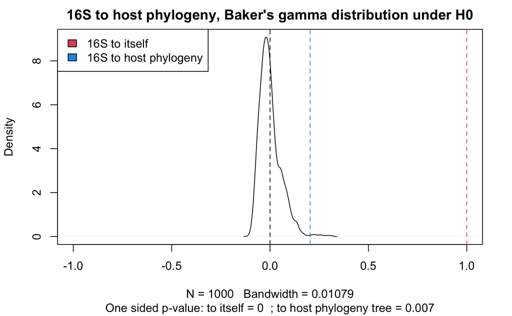

```r
title(sub = paste("One sided p-value:",
                  "to itself =",  round(sum(the_cor < cor_bakers_gamma_results)/ R, 4),
                  " ; to host phylogeny tree =",  round(sum(the_cor2 < cor_bakers_gamma_results)/ R, 4)
                  ))
```

##Fig 1C- Comparison of beta dissimilarity for each dataset

Examine overall distances in different datasets

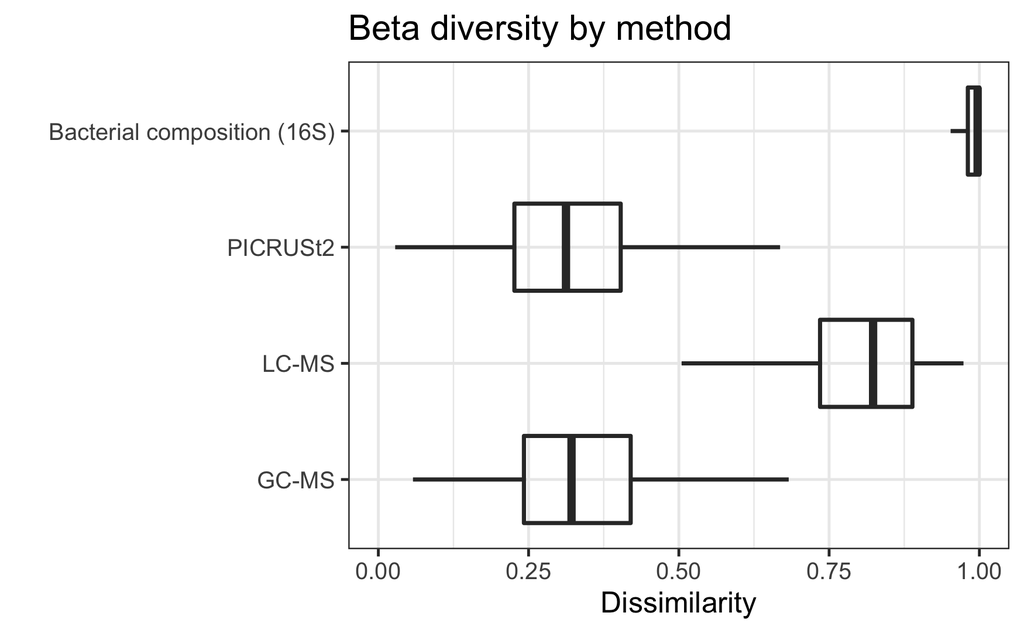

```r
##Create function to compare distances, based on a function written by Jeff Kimbrel: https://jeffkimbrel.github.io/

allDistances = function(p = ps) {

dist = phyloseq::distance(p, method = "bray")
dist.m = melt(as.matrix(dist))
# remove self-comparisons
  dist.m = dist.m %>%
    filter(as.character(Var1) != as.character(Var2)) %>%
    mutate_if(is.factor,as.character)
  #make names of comparisons and sort
  dist.m$name <- paste0(dist.m[,1],"_",dist.m[,2])
   dist.m <-dist.m[order(dist.m[,4]),]

}
##Perform on all relevant datasets

dis_asv <- allDistances(p= ps_asv)
dis_pol <- allDistances(p= ps_pol)
dis_gcms <- allDistances(p= ps_gcms)
dis_pic <- allDistances(p= ps_picrust)

##Merge into single dataframe
  dis <- data.frame(dis_asv[,4], dis_asv[,1], dis_asv[,3], dis_pic[,3], dis_pol[,3], dis_gcms[,3])
  colnames(dis) <-c("pair", "animal_1", "Bacterial composition (16S)", "PICRUSt2", "LC-MS", "GC-MS")


##Melt dataframe
  dis.melt <- melt(dis, id= c("pair", "animal_1"))
  colnames(dis.melt) <- c("pair", "animal_1", "data_type", "Distance")



# Plot the data as boxplots. First use rev to reverse the order of the factor levels.
  dis.melt$data_type <- factor(dis.melt$data_type, levels=rev(levels(dis.melt$data_type)))
  ggplot(data=dis.melt, aes(x=data_type, y=Distance)) +
    theme_bw(base_size=15) +
    geom_boxplot(outlier.shape = NA, fill=NA, size=1) +
    labs(title= "Beta diversity by method", x = "", y = "Dissimilarity")+
    ylim(0,1)+
    coord_flip()
```

Calculate adjusted p-values using one-way ANOVA analysis followed by Tukey’s test

```r
# Compute the analysis of variance
res.aov <- aov(dis.melt$Distance ~ dis.melt$data_type)
# Summary of the analysis
summary(res.aov)
```

```
                      Df Sum Sq Mean Sq F value Pr(>F)
dis.melt$data_type     3 3052.0    1017   57181 <2e-16 ***
Residuals          40396  718.7       0
---
Signif. codes:  0 ‘***’ 0.001 ‘**’ 0.01 ‘*’ 0.05 ‘.’ 0.1 ‘ ’ 1
```

```r
#Tukey's test
TukeyHSD(res.aov)
```

```
  Tukey multiple comparisons of means
    95% family-wise confidence level

Fit: aov(formula = dis.melt$Distance ~ dis.melt$data_type)

$`dis.melt$data_type`
                                             diff          lwr           upr     p adj
LC-MS-GC-MS                           0.448344147  0.443522160  0.4531661331 0.0000000
PICRUSt2-GC-MS                       -0.004718039 -0.009540026  0.0001039477 0.0578181
Bacterial composition (16S)-GC-MS     0.619384026  0.614562040  0.6242060131 0.0000000
PICRUSt2-LC-MS                       -0.453062185 -0.457884172 -0.4482401989 0.0000000
Bacterial composition (16S)-LC-MS     0.171039880  0.166217893  0.1758618666 0.0000000
Bacterial composition (16S)-PICRUSt2  0.624102065  0.619280079  0.6289240521 0.0000000
```

##Mantel and Permanova analyses

PERMANOVA analysis

```r
set.seed(42)

##Pick a dataset: ps_asv, ps_gcms, ps_pol
ps <- ps_asv

# Calculate dissimilarity matrix
dis <- phyloseq::distance(ps, method = "bray")

# Adonis test
adonis(dis ~ diet+digestive_strategy+HostOrder+HostSpecies+collection_time, data = metadata)
```

```
Call:
adonis(formula = dis ~ diet + digestive_strategy + HostOrder +      HostSpecies + collection_time, data = metadata)

Permutation: free
Number of permutations: 999

Terms added sequentially (first to last)

                    Df SumsOfSqs MeanSqs F.Model      R2 Pr(>F)
diet                 2     5.881 2.94036 12.6094 0.12760  0.001 ***
digestive_strategy   2     4.485 2.24270  9.6175 0.09732  0.001 ***
HostOrder            2     5.532 2.76578 11.8607 0.12002  0.001 ***
HostSpecies         18    12.464 0.69245  2.9695 0.27045  0.001 ***
collection_time      1     0.237 0.23651  1.0142 0.00513  0.394
Residuals           75    17.489 0.23319         0.37948
Total              100    46.088                 1.00000
---
Signif. codes:  0 ‘***’ 0.001 ‘**’ 0.01 ‘*’ 0.05 ‘.’ 0.1 ‘ ’ 1
```

For subsets analysis:

```r
set.seed(42)

##choose a dataset: ps_asv, ps_pol, ps_gcms
ps <- ps_asv
data <- as(otu_table(ps), "matrix")
```

Create one of the relevant subsets:

```r
#n=2 (change filters accordingly for n=3, 4, 5)
set.seed(42)
metadata2 <-bind_rows(
  data.frame(metadata) %>%
    group_by(HostSpecies) %>%
    filter(n()>1) %>%
    sample_n(size =2),
  data.frame(metadata) %>%
    group_by(HostSpecies) %>%
    filter(n()==1))

##Special cases for n=1:

#n=1
#set.seed(42)
#metadata2 <-    data.frame(metadata) %>%
  #group_by(HostSpecies) %>%
  #sample_n(size =1)


#Or, n=1 with median values
#ps.m <- ps.m %>%
 # group_by(OTU, HostSpecies_taxonomy) %>%
  #summarise_at(vars(Abundance), median, na.rm=TRUE)
```

Select the subset of samples from the data and run PERMANOVA test again

```r
##trim data to match subsetted samples
subset_n <- data[rownames(data) %in% metadata2$sample_name,]

##remove empty columns
subset_n <- subset_n[,colSums(subset_n)>0]
dim(subset_n)
```

```
[1]   41 4370
```

```r
#make distance matrix
dis <- vegdist(subset_n, method="bray")


adonis(dis ~ diet+digestive_strategy+HostOrder+HostSpecies+collection_time, data = metadata2)
```

```
Call:
adonis(formula = dis ~ diet + digestive_strategy + HostOrder +      HostSpecies + collection_time, data = metadata2)

Permutation: free
Number of permutations: 999

Terms added sequentially (first to last)

                   Df SumsOfSqs MeanSqs F.Model      R2 Pr(>F)
diet                2    1.5158 0.75792 2.47864 0.08132  0.001 ***
digestive_strategy  2    1.3418 0.67091 2.19409 0.07199  0.001 ***
HostOrder           2    1.5856 0.79282 2.59276 0.08507  0.001 ***
HostSpecies        18    9.4028 0.52238 1.70834 0.50444  0.001 ***
collection_time     1    0.2074 0.20741 0.67828 0.01113  0.952
Residuals          15    4.5867 0.30578         0.24607
Total              40   18.6402                 1.00000
---
Signif. codes:  0 ‘***’ 0.001 ‘**’ 0.01 ‘*’ 0.05 ‘.’ 0.1 ‘ ’ 1
```

Analysis for samples for which sex was recorded (Table S4)

```r
##Choose a dataset: ps_asv, ps_pol, ps_gcms

ps <- ps_pol

#first remove samples for which sex was not recorded
metadata2 <-subset(metadata, Sex=="F"|Sex=="M")

ps <- prune_samples(metadata2$sample_name, ps)

dis <- phyloseq::distance(ps, method = "bray")

adonis(dis ~ diet+digestive_strategy+HostOrder+HostSpecies+Sex+collection_time, data = metadata2)
```

```
Call:
adonis(formula = dis ~ diet + digestive_strategy + HostOrder +      HostSpecies + Sex + collection_time, data = metadata2)

Permutation: free
Number of permutations: 999

Terms added sequentially (first to last)

                   Df SumsOfSqs MeanSqs F.Model      R2 Pr(>F)
diet                2    5.2406 2.62028 19.3446 0.19824  0.001 ***
digestive_strategy  2    2.9618 1.48090 10.9329 0.11204  0.001 ***
HostOrder           2    3.9134 1.95670 14.4456 0.14803  0.001 ***
HostSpecies        16    6.1860 0.38662  2.8543 0.23400  0.001 ***
Sex                 1    0.1226 0.12261  0.9052 0.00464  0.533
collection_time     1    0.2907 0.29069  2.1461 0.01100  0.008 **
Residuals          57    7.7208 0.13545         0.29206
Total              81   26.4358                 1.00000
---
Signif. codes:  0 ‘***’ 0.001 ‘**’ 0.01 ‘*’ 0.05 ‘.’ 0.1 ‘ ’ 1
```

Mantel correlations

```r
dis_pol <- phyloseq::distance(ps_pol, method = "bray")
dis_gcms <- phyloseq::distance(ps_gcms, method = "bray")
dis_asv <- phyloseq::distance(ps_asv, method = "bray")

#Note: check order of samples matches
#match(attr(dis_asv,"Labels"),attr(dis_gcms,"Labels"))
#match(attr(dis_asv,"Labels"),attr(dis_pol,"Labels"))

#Perform Mantel test to compare datasets
mantel(dis_asv, dis_gcms, method="pearson", permutations = 9999)
```

```
Mantel statistic based on Pearson's product-moment correlation

Call:
mantel(xdis = dis_asv, ydis = dis_gcms, method = "pearson", permutations = 9999)

Mantel statistic r: 0.2676
      Significance: 1e-04

Upper quantiles of permutations (null model):
   90%    95%  97.5%    99%
0.0254 0.0333 0.0401 0.0479
Permutation: free
Number of permutations: 9999
```

```r
mantel(dis_asv, dis_pol, method="pearson", permutations = 9999)
```

```
Mantel statistic based on Pearson's product-moment correlation

Call:
mantel(xdis = dis_asv, ydis = dis_pol, method = "pearson", permutations = 9999)

Mantel statistic r: 0.6702
      Significance: 1e-04

Upper quantiles of permutations (null model):
   90%    95%  97.5%    99%
0.0215 0.0288 0.0346 0.0429
Permutation: free
Number of permutations: 9999
```

```r
mantel(dis_pol, dis_gcms, method="pearson", permutations = 9999)
```

```
Mantel statistic based on Pearson's product-moment correlation

Call:
mantel(xdis = dis_pol, ydis = dis_gcms, method = "pearson", permutations = 9999)

Mantel statistic r: 0.5563
      Significance: 1e-04

Upper quantiles of permutations (null model):
   90%    95%  97.5%    99%
0.0610 0.0796 0.0951 0.1156
Permutation: free
Number of permutations: 9999
```

```r
##Function to subset data as in SI (or, use one of the subsets above)
#ps_asv_subset <- subset_samples(ps_asv, HostSpecies=="Rhino")
```

Or, for subsets, first generate metadata2 as in the PERMANOVA test above for the sample subset of interest

```r
asv <- as(otu_table(ps_asv), "matrix")
gcms <- as(otu_table(ps_gcms), "matrix")
pol <- as(otu_table(ps_pol), "matrix")

##trim data accordingly
asv <- asv[rownames(asv) %in% metadata2$sample_name,]
pol <- pol[rownames(pol) %in% metadata2$sample_name,]
gcms <- gcms[rownames(gcms) %in% metadata2$sample_name,]

##remove empties
asv <- asv[,colSums(asv) >0]
pol <- pol[,colSums(pol) >0]
gcms <- gcms[,colSums(gcms) >0]

#Compare the datasets of interest, eg 16S and GC-MS
mantel(vegdist(asv), vegdist(gcms), method="pearson", permutations = 9999)
```

```
Mantel statistic based on Pearson's product-moment correlation

Call:
mantel(xdis = vegdist(asv), ydis = vegdist(gcms), method = "pearson",      permutations = 9999)

Mantel statistic r: 0.2855
      Significance: 1e-04

Upper quantiles of permutations (null model):
   90%    95%  97.5%    99%
0.0315 0.0407 0.0493 0.0599
Permutation: free
Number of permutations: 9999
```